# Hotel Booking Demand Dataset Analysis

ICY0006 Artur Nikitchuk IVSB192932

The topic of this analysis is to analyze Portugal hotels booking demand and make certain predictions based on the analysis of the data.

The dataset was taken from [Kaggle.com](https://www.kaggle.com/jessemostipak/hotel-booking-demand)

## Overview of Data

Included data is:

| Name of the column | Description |
| --- | --- |
| **hotel** | either Resort Hotel or City Hotel |
| **is_cancelled** | Value indicating if the booking was cancelled (1) or not (0) |
| **lead_time** | Number of days that elapsed between the date of booking and the arrival date |
| **arrival_date_year** | Year of arrival date |
| **arrival_date_month** | Month of arrival date |
| **arrival_date_week_number** | Week number of year for arrival date |
| **arrival_date_day_of_month** | Day of arrival date |
| **stays_in_weekend_nights** | Number of weekend nights (Saturday or Sunday) stayed or booked to stay at the hotel |
| **stays_in_week_nights** | Number of week nights (Monday to Friday) the guest stayed or booked to stay at the hotel |
| **adults** | Number of adults |
| **children** | Number of children |
| **babies** | Number of babies |
| **meal** | Type of meal booked. Categories are presented in standard hospitality meal packages: Undefined/SC – no meal package; BB – Bed & Breakfast; HB – Half board (breakfast and one other meal – usually dinne… |
| **country** | Country of origin. Categories are represented in the ISO 3155–3:2013 format |
| **market_segment** | Market segment designation. Term “TA” means “Travel Agents” and “TO” means “Tour Operators” |
| **distribution_channel** | Booking distribution channel. The term “TA” means “Travel Agents” and “TO” means “Tour Operators” |
| **is_repeated_guest** | Value indicating if the booking name was from a repeated guest (1) or not (0) |
| **previous_cancellations** | Number of previous bookings that were cancelled by the customer prior to the current booking |
| **previous_bookings_not_canceled** | Number of previous bookings not cancelled by the customer prior to the current booking |
| **reserved_room_type** | Code of room type reserved. Code is presented instead of designation for anonymity reasons. |
| **assigned_room_type** | Code for the type of room assigned to the booking. Sometimes the assigned room type differs from the reserved room type due to hotel operation reasons (e.g. overbooking) or by customer request. Code i… |
| **booking_changes** | Number of changes/amendments made to the booking from the moment the booking was created until the moment of check |
| **deposit_type** | Indication on if the customer made a deposit to guarantee the booking. This variable can assume three categories: No Deposit – no deposit was made; Non Refund – a deposit was made in the value of the … |
| **agent** | ID of the travel agency that made the booking |
| **company** | ID of the company/entity that made the booking or responsible for paying the booking. |
| **days_in_waiting_list** | Number of days the booking was in the waiting list before it was confirmed to the customer |
| **customer_type** | Type of booking, assuming one of four categories: Contract- when the booking has an allotment or other type of contract associated to it; Group – when the booking is associated to a group; Transient –… |
| **adr** | Average Daily Rate as defined by dividing the sum of all lodging transactions by the total number of staying nights |
| **required_car_parking_spaces** | Number of car parking spaces required by the customer |
| **total_of_special_requests** | Number of special requests made by the customer (e.g. twin bed or high floor) |
| **reservation_status** | Reservation last status, assuming one of three categories: Canceled – booking was canceled by the customer; Check |
| **reservation_status_date** | Date at which the last status was set. This variable can be used in conjunction with the ReservationStatus to understand when was the booking cancelled or when did the customer checked |

Lets import the dataset and have a look at the data itself.

```r
library(dplyr)
library(tibble)
library(ggcorrplot)
library(ggplot2)
hotel_data <- read.csv('data.csv')
str(hotel_data)
```

```
'data.frame':   119390 obs. of  32 variables:
 $ hotel                         : Factor w/ 2 levels "City Hotel","Resort Hotel": 2 2 2 2 2 2 2 2 2 2 ...
 $ is_canceled                   : int  0 0 0 0 0 0 0 0 1 1 ...
 $ lead_time                     : int  342 737 7 13 14 14 0 9 85 75 ...
 $ arrival_date_year             : int  2015 2015 2015 2015 2015 2015 2015 2015 2015 2015 ...
 $ arrival_date_month            : Factor w/ 12 levels "April","August",..: 6 6 6 6 6 6 6 6 6 6 ...
 $ arrival_date_week_number      : int  27 27 27 27 27 27 27 27 27 27 ...
 $ arrival_date_day_of_month     : int  1 1 1 1 1 1 1 1 1 1 ...
 $ stays_in_weekend_nights       : int  0 0 0 0 0 0 0 0 0 0 ...
 $ stays_in_week_nights          : int  0 0 1 1 2 2 2 2 3 3 ...
 $ adults                        : int  2 2 1 1 2 2 2 2 2 2 ...
 $ children                      : int  0 0 0 0 0 0 0 0 0 0 ...
 $ babies                        : int  0 0 0 0 0 0 0 0 0 0 ...
 $ meal                          : Factor w/ 5 levels "BB","FB","HB",..: 1 1 1 1 1 1 1 2 1 3 ...
 $ country                       : Factor w/ 178 levels "ABW","AGO","AIA",..: 137 137 60 60 60 60 137 137 137 137 ...
```

[output cut: 18 more lines]

```r
summary(hotel_data)
```

```
          hotel        is_canceled       lead_time   arrival_date_year arrival_date_month arrival_date_week_number
 City Hotel  :79330   Min.   :0.0000   Min.   :  0   Min.   :2015      August :13877      Min.   : 1.00
 Resort Hotel:40060   1st Qu.:0.0000   1st Qu.: 18   1st Qu.:2016      July   :12661      1st Qu.:16.00
                      Median :0.0000   Median : 69   Median :2016      May    :11791      Median :28.00
                      Mean   :0.3704   Mean   :104   Mean   :2016      October:11160      Mean   :27.17
                      3rd Qu.:1.0000   3rd Qu.:160   3rd Qu.:2017      April  :11089      3rd Qu.:38.00
                      Max.   :1.0000   Max.   :737   Max.   :2017      June   :10939      Max.   :53.00
                                                                       (Other):47873
 arrival_date_day_of_month stays_in_weekend_nights stays_in_week_nights     adults          children           babies
 Min.   : 1.0              Min.   : 0.0000         Min.   : 0.0         Min.   : 0.000   Min.   : 0.0000   Min.   : 0.000000
 1st Qu.: 8.0              1st Qu.: 0.0000         1st Qu.: 1.0         1st Qu.: 2.000   1st Qu.: 0.0000   1st Qu.: 0.000000
 Median :16.0              Median : 1.0000         Median : 2.0         Median : 2.000   Median : 0.0000   Median : 0.000000
 Mean   :15.8              Mean   : 0.9276         Mean   : 2.5         Mean   : 1.856   Mean   : 0.1039   Mean   : 0.007949
 3rd Qu.:23.0              3rd Qu.: 2.0000         3rd Qu.: 3.0         3rd Qu.: 2.000   3rd Qu.: 0.0000   3rd Qu.: 0.000000
 Max.   :31.0              Max.   :19.0000         Max.   :50.0         Max.   :55.000   Max.   :10.0000   Max.   :10.000000
                                                                                         NA's   :4
        meal          country            market_segment  distribution_channel is_repeated_guest previous_cancellations
 BB       :92310   PRT    :48590   Online TA    :56477   Corporate: 6677      Min.   :0.00000   Min.   : 0.00000
 FB       :  798   GBR    :12129   Offline TA/TO:24219   Direct   :14645      1st Qu.:0.00000   1st Qu.: 0.00000
 HB       :14463   FRA    :10415   Groups       :19811   GDS      :  193      Median :0.00000   Median : 0.00000
 SC       :10650   ESP    : 8568   Direct       :12606   TA/TO    :97870      Mean   :0.03191   Mean   : 0.08712
 Undefined: 1169   DEU    : 7287   Corporate    : 5295   Undefined:    5      3rd Qu.:0.00000   3rd Qu.: 0.00000
                   ITA    : 3766   Complementary:  743                        Max.   :1.00000   Max.   :26.00000
                   (Other):28635   (Other)      :  239
 previous_bookings_not_canceled reserved_room_type assigned_room_type booking_changes       deposit_type        agent
 Min.   : 0.0000                A      :85994      A      :74053      Min.   : 0.0000   No Deposit:104641   9      :31961
 1st Qu.: 0.0000                D      :19201      D      :25322      1st Qu.: 0.0000   Non Refund: 14587   NULL   :16340
 Median : 0.0000                E      : 6535      E      : 7806      Median : 0.0000   Refundable:   162   240    :13922
 Mean   : 0.1371                F      : 2897      F      : 3751      Mean   : 0.2211                       1      : 7191
 3rd Qu.: 0.0000                G      : 2094      G      : 2553      3rd Qu.: 0.0000                       14     : 3640
 Max.   :72.0000                B      : 1118      C      : 2375      Max.   :21.0000                       7      : 3539
                                (Other): 1551      (Other): 3530                                            (Other):42797
    company       days_in_waiting_list         customer_type        adr          required_car_parking_spaces total_of_special_requests
 NULL   :112593   Min.   :  0.000      Contract       : 4076   Min.   :  -6.38   Min.   :0.00000             Min.   :0.0000
 40     :   927   1st Qu.:  0.000      Group          :  577   1st Qu.:  69.29   1st Qu.:0.00000             1st Qu.:0.0000
 223    :   784   Median :  0.000      Transient      :89613   Median :  94.58   Median :0.00000             Median :0.0000
 67     :   267   Mean   :  2.321      Transient-Party:25124   Mean   : 101.83   Mean   :0.06252             Mean   :0.5714
 45     :   250   3rd Qu.:  0.000                              3rd Qu.: 126.00   3rd Qu.:0.00000             3rd Qu.:1.0000
 153    :   215   Max.   :391.000                              Max.   :5400.00   Max.   :8.00000             Max.   :5.0000
 (Other):  4354
 reservation_status reservation_status_date
 Canceled :43017    2015-10-21:  1461
 Check-Out:75166    2015-07-06:   805
 No-Show  : 1207    2016-11-25:   790
                    2015-01-01:   763
                    2016-01-18:   625
                    2015-07-02:   469
                    (Other)   :114477
```

## Dealing with missing values

We can see that there are 4 missing values in ‘Children’ column. Lets see where these missing values are.

```r
n <- length(hotel_data$children)
for (i in 1:n) {
  if (is.na(hotel_data$children[i]))
    cat("Missing value found at line: ", i, "\n")
}
```

```
Missing value found at line:  40601
Missing value found at line:  40668
Missing value found at line:  40680
Missing value found at line:  41161
```

Lets assume, that if the column is missing, then there were no children and replace missing values with 0.

```r
n <- length(hotel_data$children)
for (i in 1:n) {
  if (is.na(hotel_data$children[i]))
    hotel_data$children[i] <- 0
}
```

```r
hotel_data$agent <- NULL
```

Under “meal” column, there are 1169 undefined. For convenience, lets change undefined ones to SC(which both mean no meal package) and remove the undefined level.

```r
hotel_data$meal <-replace(hotel_data$meal,hotel_data$meal=='Undefined','SC')
hotel_data$meal <- factor(hotel_data$meal)
```

## Basic Visual Graphs

There two types of hotels: Resort Hotel and City Hotel

```r
table(hotel_data$hotel)
```

```
  City Hotel Resort Hotel
       79330        40060
```

And lets turn the numbers into something more beautiful to look at:

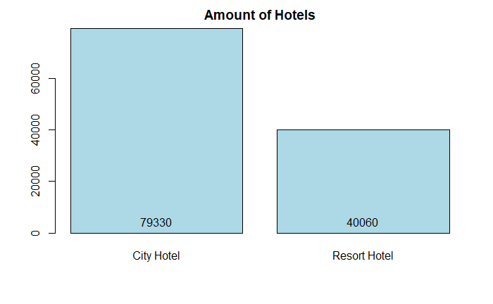

```r
hotel_table <-table(hotel_data$hotel)
hotel_bar <-barplot(hotel_table, main='Amount of Hotels', col='light blue')
text(hotel_bar, 0, hotel_table, cex=1,pos=3 )
```

There are 79330/40060≈**1.98** times more City Hotels over Resort Hotels.  
Amount of bookings by year

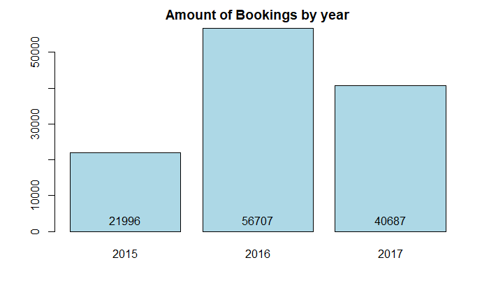

```r
hotel_bar <- barplot(table(hotel_data$arrival_date_year), main='Amount of Bookings by year', col='light blue')
text(hotel_bar, 0, table(hotel_data$arrival_date_year), cex=1,pos=3 )
```

The year 2016 had the most bookings  
Amount of bookings by month

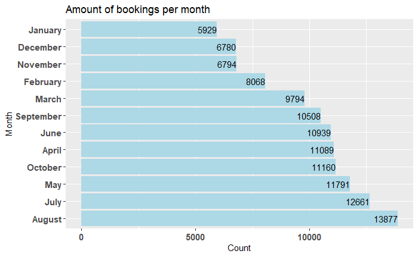

```r
library(ggplot2)
require(forcats)
ggplot(data = hotel_data, aes(x = fct_infreq(arrival_date_month))) +
  geom_bar(stat = "count", fill='light blue') +
  geom_text(stat = "count", aes(label = ..count..), hjust = 1,size=4) +
  coord_flip() + labs(title = "Amount of bookings per month",
                      x = "Month",
                      y = "Count") +
  theme(axis.text.x = element_text(face="bold", size=11),axis.text.y = element_text(face="bold", size=11))
```

Top 3 months by the amount of bookings are May, July and August.

Lets have a look at the countries

```r
library(dplyr)
hotel_data%>%
  group_by(country)%>%
  summarise(num=n())%>%
  arrange(desc(num))
```

| country | num |
| --- | --- |
| PRT | 48590 |
| GBR | 12129 |
| FRA | 10415 |
| ESP | 8568 |
| DEU | 7287 |
| ITA | 3766 |
| IRL | 3375 |
| BEL | 2342 |
| BRA | 2224 |
| NLD | 2104 |

[output cut: 168 more lines]

We can see that most visitors come from Portugal. Then come visitors from other European countries like The United Kingdom, France, Spain and Germany.

Lets visualize, how many people are coming from Portugal, and how many people are coming from foreign countries.

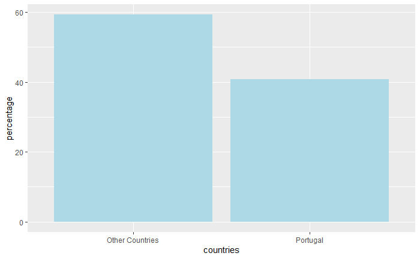

```r
Portugal <- round(mean(hotel_data$country == "PRT"), 3) * 100
not_Portugal <- round(mean(hotel_data$country != "PRT"), 3) * 100
df <- data.frame(
  countries=c("Portugal", "Other Countries"),
  percentage=c(Portugal,not_Portugal)
)
ggplot(data = df, aes(x=countries, y=percentage)) +
  geom_bar(stat = "identity", fill="light blue")
```

As we can see, over 40% of visitors are from Portugal.

## Cancellations

Lets have a look at cancellations by a hotel type.

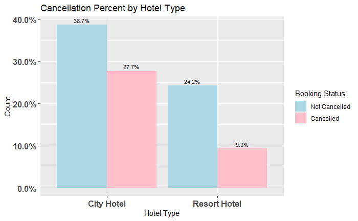

```r
ggplot(data = hotel_data,aes(x = hotel,y = prop.table(stat(count)),fill = factor(is_canceled),
         label = scales::percent(prop.table(stat(count))))) +
geom_bar(position = position_dodge()) +

geom_text(stat = "count",position = position_dodge(.9),vjust = -0.5,size = 3) +
theme(axis.text.x = element_text(face="bold", size=12),axis.text.y = element_text(face="bold", size=12))+
scale_y_continuous(labels = scales::percent) +

labs(title = "Cancellation Percent by Hotel Type",x = "Hotel Type",y = "Count") +
scale_fill_manual(
    name = "Booking Status",
    breaks = c("0", "1"),
    labels = c("Not Cancelled", "Cancelled"),
    values = c("0" = "light blue", "1"="pink")
  )
```

It is clear that Resort Hotel cancel ratio is way smaller than for city hotels.

General reservation status overview.

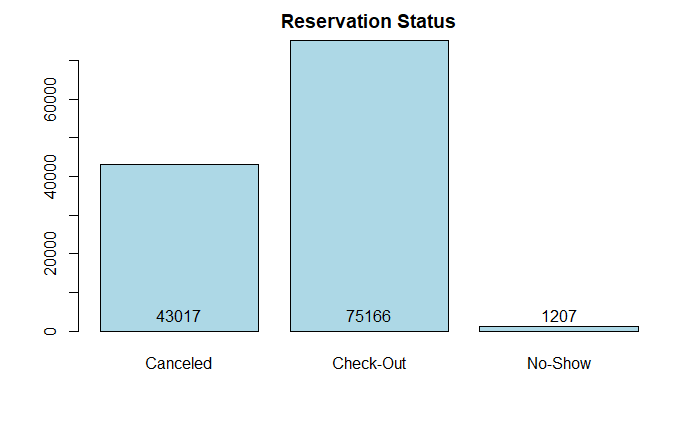

```r
hotel_bar <- barplot(table(hotel_data$reservation_status), main='Reservation Status', col='light blue')
text(hotel_bar, 0, table(hotel_data$reservation_status), cex=1,pos=3 )
```

Distribution type plays a role in cancellation. From the graph it can be seen that most bookings are made by travel agencies or travel organisations, they also have the highest percent of cancellations.

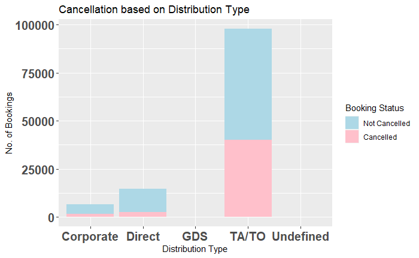

```r
 ggplot(hotel_data,aes(x=factor(distribution_channel),fill=factor(is_canceled)))+
             geom_bar()+theme(axis.text.x = element_text(face="bold", size=15),
             axis.text.y = element_text(face="bold", size=15))+

             labs(
                title = "Cancellation based on Distribution Type",
                x = "Distribution Type",
                y = "No. of Bookings",size=15) +
            scale_fill_manual(
                name = "Booking Status",
                breaks = c("0", "1"),
                labels = c("Not Cancelled", "Cancelled"),
                values = c("0" = "light blue", "1"="pink")
  )
```

Lets do some calculations and, for the sake of our convenience, add some precalculated columns. ADR basically means average cost per night. Lets add two more columns: total nights stayed, and total cost for all of the nights.

```r
hotel_data <- mutate(hotel_data,
       stay_nights_total = stays_in_weekend_nights + stays_in_week_nights,
       stay_cost_total = adr * stay_nights_total)
```

Minimal, median, mean and max price of stays:

```r
t <- subset(hotel_data, subset = hotel_data$stay_cost_total > 0)
summary(t$stay_cost_total)
```

```
   Min. 1st Qu.  Median    Mean 3rd Qu.    Max.
    1.0   151.0   270.0   363.8   450.0  7590.0
```

```r
t <- subset(t, subset = t$is_canceled == 0)
summary(t$stay_cost_total)
```

```
   Min. 1st Qu.  Median    Mean 3rd Qu.    Max.
    1.0   147.0   264.6   354.1   446.5  7590.0
```

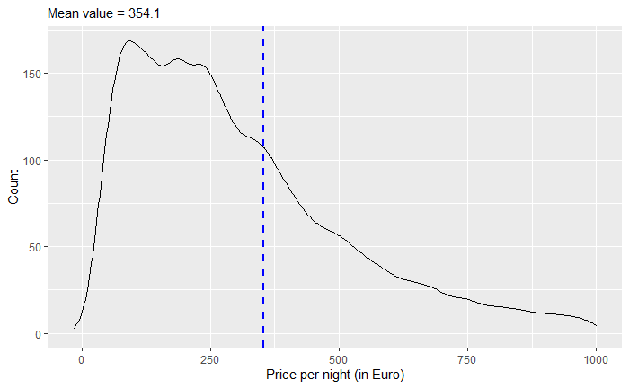

```r
p <- ggplot(t, aes(x=stay_cost_total, y=..count..)) +
  geom_density()+
  xlim(-15,1000)+
  labs(
       x = "Price per night (in Euro)",
       y="Count",
       subtitle = "Mean value = 354.1")

p+ geom_vline(aes(xintercept=mean(stay_cost_total)),
            color="blue", linetype="dashed", size=1)
```

City hotel:

```r
nc_city_hotel   <- subset(t, subset = t$hotel != "Resort Hotel")
nc_resort_hotel <- subset(t, subset = t$hotel == "Resort Hotel")
summary(nc_city_hotel$stay_cost_total)
```

```
   Min. 1st Qu.  Median    Mean 3rd Qu.    Max.
    1.0   170.0   270.0   318.8   406.1  3910.0
```

Resort hotel:

```r
summary(nc_resort_hotel$stay_cost_total)
```

```
   Min. 1st Qu.  Median    Mean 3rd Qu.    Max.
    4.0   110.0   256.0   410.4   560.0  7590.0
```

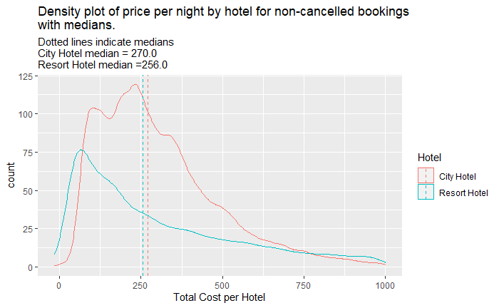

```r
ggplot(t, aes(x=stay_cost_total, y = ..count.., color=t$hotel)) +
  geom_density()+
  geom_vline(data=nc_city_hotel, aes(xintercept=median(nc_city_hotel$stay_cost_total), color=nc_city_hotel$hotel),
             linetype="dashed")+
  geom_vline(data=nc_resort_hotel, aes(xintercept=median(nc_resort_hotel$stay_cost_total), color=nc_resort_hotel$hotel),
             linetype="dashed")+
  xlim(-15, 1000)+
  labs(x = "Total Cost per Hotel", title = "Density plot of price per night by hotel for non-cancelled bookings \nwith medians.", subtitle = "Dotted lines indicate medians\nCity Hotel median = 270.0 \nResort Hotel median =256.0", color="Hotel")
```

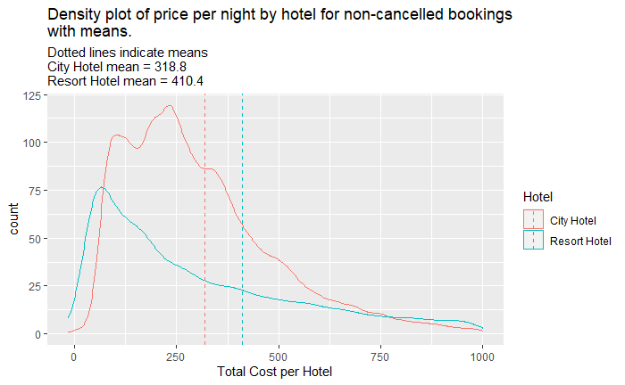

```r
ggplot(t, aes(x=stay_cost_total, y = ..count.., color=t$hotel)) +
  geom_density()+
  geom_vline(data=nc_city_hotel, aes(xintercept=mean(nc_city_hotel$stay_cost_total), color=nc_city_hotel$hotel),
             linetype="dashed")+
  geom_vline(data=nc_resort_hotel, aes(xintercept=mean(nc_resort_hotel$stay_cost_total), color=nc_resort_hotel$hotel),
             linetype="dashed")+
  xlim(-15, 1000)+
  labs(x = "Total Cost per Hotel", title = "Density plot of price per night by hotel for non-cancelled bookings \nwith means.", subtitle = "Dotted lines indicate means\nCity Hotel mean = 318.8 \nResort Hotel mean = 410.4", color="Hotel")
```

Lead time in days chart. Lead time means how many days in advance was the booking created.

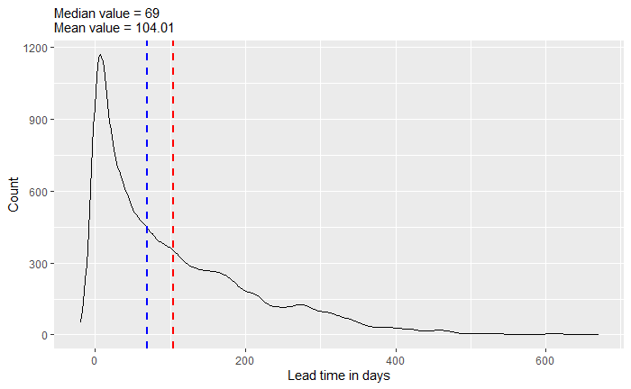

```r
p <- ggplot(hotel_data, aes(x=hotel_data$lead_time, y=..count..)) +
  geom_density()+
  xlim(-15,1000)+
  labs(
       x = "Lead time in days",
       y="Count",
       subtitle = "Median value = 69\nMean value = 104.01")+
  xlim(-20, 670)
p+ geom_vline(aes(xintercept=median(lead_time)),
            color="blue", linetype="dashed", size=1)+
   geom_vline(aes(xintercept=mean(lead_time)),
            color="red", linetype="dashed", size=1)
```

Amount of nights stayed total

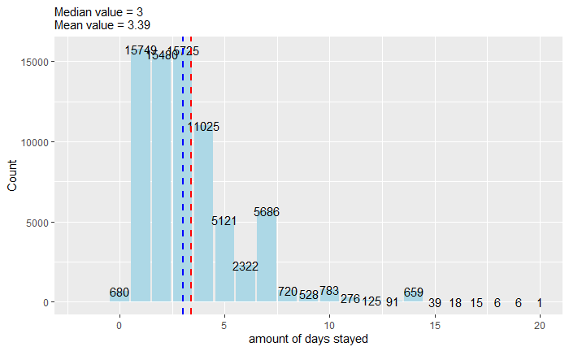

```r
checked_out <- subset(hotel_data, subset = hotel_data$reservation_status == "Check-Out")
p <- ggplot(checked_out, aes(x=checked_out$stay_nights_total, y=..count..)) +
  geom_bar(fill="light blue", position = position_dodge(width = 3))+
  geom_text(stat = "count", aes(label = ..count..),size=4)+
  xlim(-15,1000)+
  labs(
       x = "amount of days stayed",
       y="Count",
       subtitle = "Median value = 3\nMean value = 3.39")+
  xlim(-2,20)
p+ geom_vline(aes(xintercept=median(stay_nights_total)),
            color="blue", linetype="dashed", size=1)+
   geom_vline(aes(xintercept=mean(stay_nights_total)),
            color="red", linetype="dashed", size=1)
```

Most people prefer to stay 1-3 days.

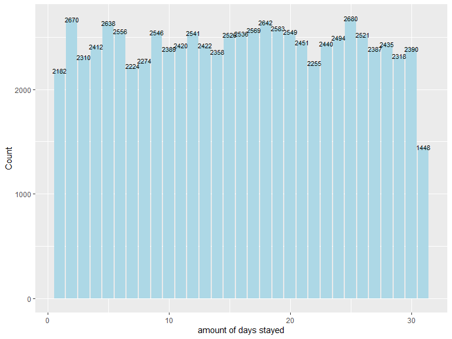

```r
checked_out <- subset(hotel_data, subset = hotel_data$reservation_status == "Check-Out")
p <- ggplot(checked_out, aes(x=checked_out$arrival_date_day_of_month, y=..count..)) +
  geom_bar(fill="light blue")+
  geom_text(stat = "count", aes(label = ..count..),size=3)+
  labs(
       x = "amount of days stayed",
       y="Count")
p
```

Besides 31st day of the month, there is no preference, when it comes to choosing which day to arrive. The 31st dip can be explained by December 31st, when most people are probably already in a hotel.

# Data Modelling

### Correlations yay!

Lets convert all factors to numeric and calculate our correlation coefficient between is_canceled variable and the others.

```r
hotel_data_numeric <- hotel_data %>% mutate_if(is.factor, as.numeric)
canceled_cor <- data.frame(sapply(hotel_data_numeric, cor, y=hotel_data_numeric$is_canceled))
colnames(canceled_cor) <- "coefficient"
```

```r
canceled_cor <- subset(canceled_cor, subset = canceled_cor$coefficient < -0.1 | canceled_cor$coefficient > 0.1)
library(tibble)
canceled_cor <-rownames_to_column(canceled_cor, var = "feature") %>% arrange(desc(coefficient))
canceled_cor %>% knitr::kable()
```

| feature | coefficient |
| --- | --- |
| is_canceled | 1.0000000 |
| deposit_type | 0.4686338 |
| lead_time | 0.2931234 |
| country | 0.2688011 |
| distribution_channel | 0.1676003 |
| previous_cancellations | 0.1101328 |
| hotel | -0.1365313 |
| booking_changes | -0.1443810 |
| reservation_status_date | -0.1621348 |
| assigned_room_type | -0.1760277 |
| required_car_parking_spaces | -0.1954978 |
| total_of_special_requests | -0.2346578 |
| reservation_status | -0.9171960 |

Judging by the feature-coefficient table, it is clear that deposit type, lead time and country have the strongest correlation. Deposit type might influence people to cancel less. For example if a booking is made in a no-refund hotel, the client is more likely to actually go to that hotel. Hotel giving a refund gives the client more leeway in cancelling and re-deciding the hotel. Next one is lead time(days until the booking). The more days there is until the booking, the more time the client has to rethink the trip and there’s more risk, that the client will find a better option. The third one is country. Previously it was mentioned, that the hotels are in Portugal. It might be that the Portuguese clients are less likely to cancel, because for them there are less things that might stop them from going to the hotel, while foreign tourists have more things that can influence their arrival to the hotel like cancelled flights or pandemics.

Lets only use the needed columns in our data and discard unnecessary ones and print correlation plot

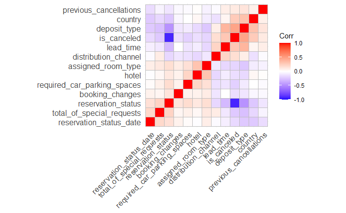

```r
hotel_data_numeric <- hotel_data_numeric %>% select(canceled_cor$feature)
ggcorrplot(cor(hotel_data_numeric), hc.order = TRUE)
```

Reservation status leaks data to is_canceled column, so we should remove it. Also, reservation_status_date doesn’t really give us any info, we should remove that too.

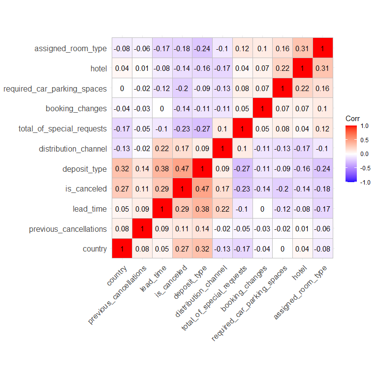

```r
hotel_data_numeric$reservation_status <- NULL
hotel_data_numeric$reservation_status_date <- NULL
ggcorrplot(cor(hotel_data_numeric), hc.order = TRUE, lab = TRUE)
```

Lets try to draw a scatter plot between is_canceled and lead_time

```r
p <- plot(is_canceled~lead_time, data=hotel_data_numeric, col="light blue", yaxt = "n")
ytick<-seq(0, 1, by=1)
axis(side=2, at=ytick, labels = FALSE)
```

[figure not shown]

```r
text(par("usr")[1], ytick,
     labels = ytick, srt = 90, pos = 2, xpd = TRUE)
```

Looking at the plot, it is clear that, linear regression is not applicable here and we should turn to logistic regression. This is because the is_cancelled feature can only be either a 0 or 1. The difference between logistic and linear regression:

| Logistic regression | Linear regression |
| --- | --- |
| Logistic Regression is used to predict the categorical dependent variable using a given set of independent variables. | Linear regression is used to predict the continuous dependent variable using a given set of independent variables. |
| Logistic regression is used for solving Classification problems. | Linear Regression is used for solving Regression problem. |
| Maximum likelihood estimation method is used for estimation of accuracy. | Least square estimation method is used for estimation of accuracy. |
| The output of Logistic Regression must be a Categorical value such as 0 or 1, Yes or No, etc. | The output for Linear Regression must be a continuous value, such as price, age, etc. |
| In Logistic regression, it is not required to have the linear relationship between the dependent and independent variable. | In Linear regression, it is required that relationship between dependent variable and independent variable must be linear. |
| In logistic regression, there should not be collinearity between the independent variable. | In linear regression, there may be collinearity between the independent variables. |
| In logistic Regression, we predict the values of categorical variables. | In Linear regression, we predict the value of continuous variables. |

Lets split our dataset into two sets: 70% is training set, and 30% is testing set. Next, lets train the regression model on our training set.

```r
set.seed(1337)
index <- sample(nrow(hotel_data_numeric), nrow(hotel_data_numeric)*0.3)
test <- hotel_data_numeric[index,] # assign 30% of data to our test variable
training <-hotel_data_numeric[-index,] # assign remaining 70% of data to our training variable
train_model <- glm(is_canceled~., family = "binomial", data=training) # Do the training
```

```
glm.fit: fitted probabilities numerically 0 or 1 occurred
```

```r
# IDK why but when this is included in the notebook, the notebook glitches and nothing after the summary is being shown :(
#summary(train_model)
```

and now lets test our model on a testing set.

```r
test$probability <- predict(train_model, test, type="response")
test$prediction <- ifelse(test$probability>0.5, "1" ,"0")
mean(test$is_canceled == test$prediction)
```

```
[1] 0.7687411
```

```r
table(test$is_canceled == test$prediction)
```

```
FALSE  TRUE
 8283 27534
```

Logistic regression shows an accuracy of 76.9%

Lets have a look at ROC and AUC parameters, but first lets convert them to numeric values. The graph shows the performance of our model at different thresholds (sensitivity vs specificity). Sensitivity shows us the true positive rate and specificity shows us the false positive rate.

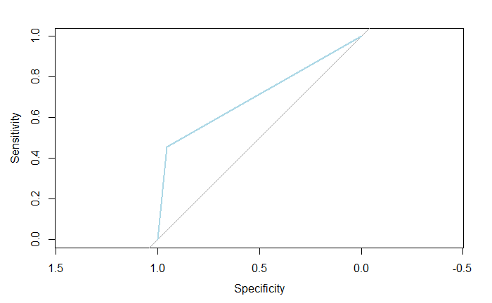

```r
library(pROC)
test$is_canceled <- as.numeric(test$is_canceled)
test$prediction <- as.numeric(test$prediction)
ROC <- roc(test$is_canceled, test$prediction)
plot(ROC, col='light blue')
```

And lets have a look at the AUC value:

```r
auc(ROC)
```

```
Area under the curve: 0.7045
```

AUC - ROC curve is a performance measurement for classification problem at various thresholds settings. ROC is a probability curve and AUC represents degree or measure of separability. It tells how much model is capable of distinguishing between classes. Higher the AUC, better the model is at predicting 0s as 0s and 1s as 1s.(Sarang Narkhede, 2018) So basically our model coud predict around 70% right, which is quite good!

# Lottery probability

The Powerball lotto is made up of 6 total numbers randomly selected twice per week. The first 5 numbers (white) are between 1 and 69. The final number (red) is called the Powerball. It can be anywhere between 1 and 26. When purchasing a ticket, players can select all 6 numbers themselves or do a “quick pick” and receive a randomly generated set of numbers.

#### n! / r! (n-r)!

n - amount of numbers to select from is 69 and 26 for Powerball.  
r - how many we can select (e.g. 5 or 1 for Powerball number).

### Top prize: 5 correct numbers + 1 correct powerball - all five numbers and powerball are correctly guessed:

First lets calculate possible combinations for first 5 numbers

```
69! / 5! * (69 - 5)! = 11,238,513
```

For powerball the probability is 1/26. Therefore, for us to calculate the probability of winning the lottery, we need to calculate the probability of picking first 5 numbers correctly (1 in 11,238,513) and the powerball (1 in 26). This can be achieved by a simple multiplication.

```
1 / 11,238,513 * 1 / 26 = 1 / 292,201,338
```

### Second prize: 5 + 0 - all five numbers have to be guessed and Powerball not guessed

The probability to guess 5 numbers is the same as above:

```
1/11,238,513
```

Now lets calculate the probability of not choosing the right powerball number. There are **26-1=25** incorrect numbers to choose. So, the probablity is 25/26. Lets do a similar multiplication again:

```
1 / 11,238,513 * 25 / 26 = 25/ 292,201,338 = 1/11,688,053.52
```

### Third prize: 4 + 1 - guess 4 out of 5 selected numbers + powerball number

Previously it was calculated that the amount of combinations is 11,238,513 Powerball probability is 1/26 lets calculate the number of ways in which 4 numbers can be chosen correctly out of 5 numbers drawn.

```
5!/4!*1! * 64!/63!*1! = 320
```

The chances are 320 in 11,238,513 of correctly choosing 4 out of 5 numbers in the first part. Now lets add the possibility of picking the right powerball

```
320 * 1/11,238,513 * 1/26 = 1/913,129.18125
```

### Fourth prize: 4 + 0 - guess 4 out of 5 selected numbers and no powerball number

Lets use the same logic as above:

```
320 * 1/11,238,513 * 25/26 = 36,525.16725
```

### Fifth prize: 3 + 1 - guess 3 out of 5 selected numbers + powerball number

There are 20,160 different ways in which 3 numbers out of 5 can be drawn:

```
5!/3!*2! * 64!/62!*2! = 20,160
```

3 out of 5 + powerball

```
20,160 * 1/11,238,513 * 1/26 = 1/14,494
```

### Sixth prize: 3 + 0 - guess 3 out of 5 selected numbers and no powerball number

```
20,160 * 1/11,238,513 * 25/26 = 1/579
```

### Seventh prize: 2 + 1 - guess 2 out of 5 selected numbers + powerball number

Guess 2 out of 5

```
5!/2!*3! * 64!/61!*3! = 416,640
```

2 out of 5 + powerball

```
416,640 * 1/11,238,513 * 1/26 = 1/701.33
```

### Eigth prize: 1 + 1 - guess 1 out of 5 selected numbers + powerball number

Guess 1 out of 5

```
5!/1!*4! * 64!/60!*4! = 3,176,880
```

1 out of 5 + powerball

```
3,176,880 * 1/11,238,513 * 1/26 = 1/92
```

### Last prize: 0 + 1 - guess 0 out of 5 selected numbers + powerball number

Guess 0 out of 5

```
5!/0!*5! * 64!/59!*5! = 7,624,512
```

0 out of 5 + powerball

```
7,624,512 * 1/11,238,513 * 1/26 = 1/38.32
```

Looking a the numbers, it is clear why most people lose; infact, that is the whole business-scheme of lottery businesses. Make people believe they can win, and make them do emotion-driven purchases.

sources: Sarang Narkhede (2018 June 26). Understanding AUC - ROC Curve. https://towardsdatascience.com/understanding-auc-roc-curve-68b2303cc9c5